# A7: Kickstarter

Author

Riwoo Kim

Published

February 27, 2026

## A7: Kickstarter

### Loading Libraries

```r
library(dplyr)
library(ggplot2)
```

### Loading Data

```r
Sys.setlocale("LC_ALL", "English")
```

```
[1] ""
```

```r
ks_data <- read.csv("~/Downloads/ks-projects-201801.csv", stringsAsFactors = FALSE)

ks_data |> glimpse()
```

```
Rows: 378,661
Columns: 15
$ ID               <int> 1000002330, 1000003930, 1000004038, 1000007540, 10000…
$ name             <chr> "The Songs of Adelaide & Abullah", "Greeting From Ear…
$ category         <chr> "Poetry", "Narrative Film", "Narrative Film", "Music"…
$ main_category    <chr> "Publishing", "Film & Video", "Film & Video", "Music"…
$ currency         <chr> "GBP", "USD", "USD", "USD", "USD", "USD", "USD", "USD…
$ deadline         <chr> "2015-10-09", "2017-11-01", "2013-02-26", "2012-04-16…
$ goal             <dbl> 1000, 30000, 45000, 5000, 19500, 50000, 1000, 25000, …
$ launched         <chr> "2015-08-11 12:12:28", "2017-09-02 04:43:57", "2013-0…
$ pledged          <dbl> 0.00, 2421.00, 220.00, 1.00, 1283.00, 52375.00, 1205.…
$ state            <chr> "failed", "failed", "failed", "failed", "canceled", "…
$ backers          <int> 0, 15, 3, 1, 14, 224, 16, 40, 58, 43, 0, 100, 0, 0, 7…
$ country          <chr> "GB", "US", "US", "US", "US", "US", "US", "US", "US",…
$ usd.pledged      <dbl> 0.00, 100.00, 220.00, 1.00, 1283.00, 52375.00, 1205.0…
$ usd_pledged_real <dbl> 0.00, 2421.00, 220.00, 1.00, 1283.00, 52375.00, 1205.…
$ usd_goal_real    <dbl> 1533.95, 30000.00, 45000.00, 5000.00, 19500.00, 50000…
```

### Processing Data

```r
ks_data <- ks_data |>
  mutate(
    deadline_date = as.Date(deadline),
    launched_date = as.Date(launched),
    deadline_year = format(deadline_date, "%Y"),
    launched_year = format(launched_date, "%Y")
  )

ks_data |>
  select(deadline_date, launched_date, deadline_year, launched_year) |>
  glimpse()
```

```
Rows: 378,661
Columns: 4
$ deadline_date <date> 2015-10-09, 2017-11-01, 2013-02-26, 2012-04-16, 2015-08…
$ launched_date <date> 2015-08-11, 2017-09-02, 2013-01-12, 2012-03-17, 2015-07…
$ deadline_year <chr> "2015", "2017", "2013", "2012", "2015", "2016", "2014", …
$ launched_year <chr> "2015", "2017", "2013", "2012", "2015", "2016", "2014", …
```

### Initial Calculations

```r
total_n <- nrow(ks_data)
success_n <- ks_data |> filter(state == "successful") |> nrow()
failed_n <- ks_data |> filter(state == "failed") |> nrow()
failed_pct <- (failed_n / total_n) * 100

total_n
```

```
[1] 378661
```

```r
success_n
```

```
[1] 133956
```

```r
failed_n
```

```
[1] 197719
```

```r
failed_pct
```

```
[1] 52.21531
```

After analyzing the data, I found that there are a total of **378661** projects. There are **133956** successful projects and **197719** failed projects. The failure rate was about **52.215306%** for all projects.

### Biggest Non-Success

```r
biggest_non_success <- ks_data |>
  filter(state != "successful") |>
  filter(usd_pledged_real == max(usd_pledged_real, na.rm = TRUE))

biggest_non_success |> select(name, state, usd_pledged_real, goal)
```

```
                                                     name     state
1 The Skarp Laser Razor: 21st Century Shaving (Suspended) suspended
  usd_pledged_real   goal
1          4005111 160000
```

The biggest non success project is “The Skarp Laser Razor”, which has raised more than $4 million through a new idea that lets people shave without hurting their skin using lasers. However in 2015, Kickstarter stopped the project because it didn’t follow the rules about presenting working prototypes. Since then, the company has moved its platform to Indiegogo to raise more money but it has not launched or delivered any products until 2026. This is because the company went bankrupt and had a legal dispute with the co-founder.

### Project State

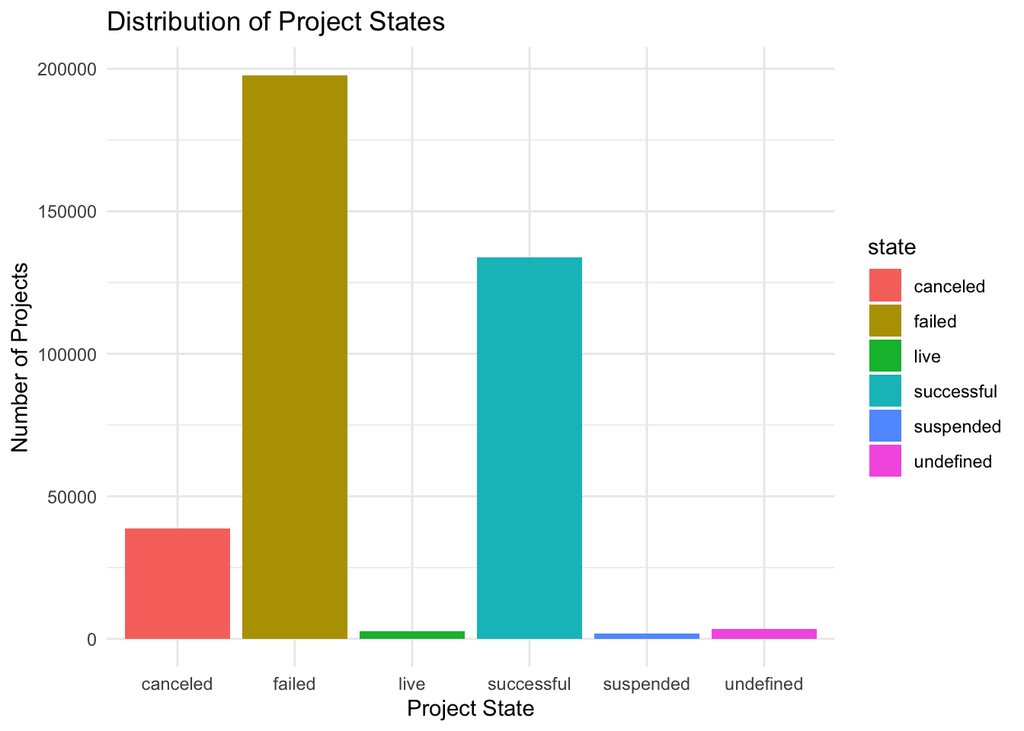

```r
state_summary <- ks_data |>
  group_by(state) |>
  summarize(count = n())

ggplot(state_summary, aes(x = state, y = count, fill = state)) +
  geom_col() +
  labs(title = "Distribution of Project States",
       x = "Project State",
       y = "Number of Projects") +
  theme_minimal()
```

### Yearly Summary

```r
yearly_summary <- ks_data |>
  group_by(launched_year) |>
  summarize(
    count = n(),
    percent_success = (sum(state == "successful") / n()) * 100,
    avg_pledged = mean(usd_pledged_real, na.rm = TRUE)
  )

yearly_summary |> print()
```

```
# A tibble: 11 × 4
   launched_year count percent_success avg_pledged
   <chr>         <int>           <dbl>       <dbl>
 1 1970              7             0            0
 2 2009           1329            43.6       2141.
 3 2010          10519            43.7       2800.
 4 2011          26237            46.4       3954.
 5 2012          41165            43.5       7833.
 6 2013          44851            43.3      10670.
 7 2014          67745            31.2       7744.
 8 2015          77300            27.1       8895.
 9 2016          57184            32.8      11488.
10 2017          52200            35.4      11954.
11 2018            124             0          510.
```

I thought it was more meaningful to look at the trends when the project first hit the market. So, I based it on the launch year instead of the deadline year. The success rate was defined as the percentage of projects that were clearly identified as ‘successful’ among the overall project status. This is the most intuitive way to know if a project has achieved its goals. I can’t accurately measure the total amount of money raised because the number of projects can affect the sum. To find the average amount of money per project, I used the mean of usd_pledged_real.

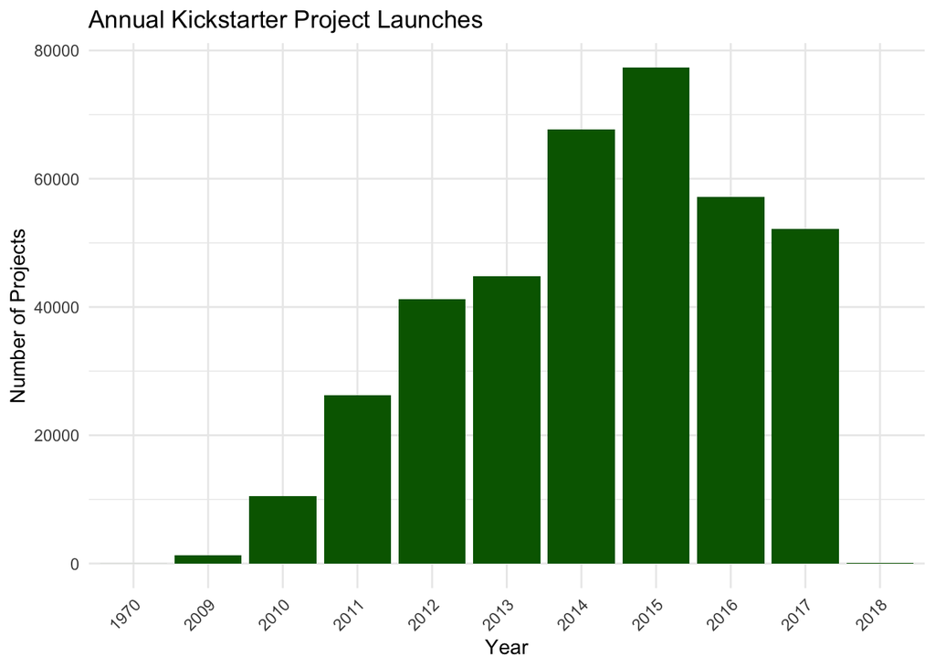

```r
ggplot(yearly_summary, aes(x = launched_year, y = count)) +
  geom_col(fill = "darkgreen") +
  labs(title = "Annual Kickstarter Project Launches",
       x = "Year",
       y = "Number of Projects") +
  theme_minimal() +
  theme(axis.text.x = element_text(angle = 45, hjust = 1))
```

Look into the data, the number of projects has increased a lot since the launch in 2009, peaking at 77,300 in 2015. But the interesting point is the number of projects was the highest in 2015, but the success rate was about 27.1% which is lower than in other years. This suggests that the popularization of the platform may have resulted in fierce competition or the influx of low-quality projects.

### Unusual data values

launched_year data: 1970

The yearly summary data shows that 7 projects started in 1970. However Kickstarter is started in 2009, so a project from 1970 would be incorrect. Also, there are a lot more data from other years but only 7 data from 1970. So I think this shows that the data from 1970 is not a normal record.

I think this data was caused by the time the computer system designated as the default when the date value was missing. If the time data isn’t entered into the computer system, sometimes it just stores as the default value. In this case, the default value is 1970, so it seems to be stored as such. So it’s not the actual 1970 record, but the projects that lost the launch date information during the data collection process.

“Is there a way to find the actual launch date of the 7 projects recorded as 1970 via server logs or other database fields?”